# Projekt_titanic

2024-11-25

```r
library(titanic)
# Wczytanie danych Titanic
data_titanic <- titanic::titanic_train
```

```r
head(data_titanic)
```

```
##   PassengerId Survived Pclass
## 1           1        0      3
## 2           2        1      1
## 3           3        1      3
## 4           4        1      1
## 5           5        0      3
## 6           6        0      3
##                                                  Name    Sex Age SibSp Parch
## 1                             Braund, Mr. Owen Harris   male  22     1     0
## 2 Cumings, Mrs. John Bradley (Florence Briggs Thayer) female  38     1     0
## 3                              Heikkinen, Miss. Laina female  26     0     0
## 4        Futrelle, Mrs. Jacques Heath (Lily May Peel) female  35     1     0
## 5                            Allen, Mr. William Henry   male  35     0     0
## 6                                    Moran, Mr. James   male  NA     0     0
##             Ticket    Fare Cabin Embarked
## 1        A/5 21171  7.2500              S
## 2         PC 17599 71.2833   C85        C
## 3 STON/O2. 3101282  7.9250              S
## 4           113803 53.1000  C123        S
## 5           373450  8.0500              S
## 6           330877  8.4583              Q
```

```r
# Sprawdzenie struktury danych
str(data_titanic)
```

```
## 'data.frame':    891 obs. of  12 variables:
##  $ PassengerId: int  1 2 3 4 5 6 7 8 9 10 ...
##  $ Survived   : int  0 1 1 1 0 0 0 0 1 1 ...
##  $ Pclass     : int  3 1 3 1 3 3 1 3 3 2 ...
##  $ Name       : chr  "Braund, Mr. Owen Harris" "Cumings, Mrs. John Bradley (Florence Briggs Thayer)" "Heikkinen, Miss. Laina" "Futrelle, Mrs. Jacques Heath (Lily May Peel)" ...
##  $ Sex        : chr  "male" "female" "female" "female" ...
##  $ Age        : num  22 38 26 35 35 NA 54 2 27 14 ...
##  $ SibSp      : int  1 1 0 1 0 0 0 3 0 1 ...
##  $ Parch      : int  0 0 0 0 0 0 0 1 2 0 ...
##  $ Ticket     : chr  "A/5 21171" "PC 17599" "STON/O2. 3101282" "113803" ...
##  $ Fare       : num  7.25 71.28 7.92 53.1 8.05 ...
##  $ Cabin      : chr  "" "C85" "" "C123" ...
##  $ Embarked   : chr  "S" "C" "S" "S" ...
```

```r
# Podstawowe statystyki opisowe
summary(data_titanic)
```

```
##   PassengerId       Survived          Pclass          Name
##  Min.   :  1.0   Min.   :0.0000   Min.   :1.000   Length:891
##  1st Qu.:223.5   1st Qu.:0.0000   1st Qu.:2.000   Class :character
##  Median :446.0   Median :0.0000   Median :3.000   Mode  :character
##  Mean   :446.0   Mean   :0.3838   Mean   :2.309
##  3rd Qu.:668.5   3rd Qu.:1.0000   3rd Qu.:3.000
##  Max.   :891.0   Max.   :1.0000   Max.   :3.000
##
##      Sex                 Age            SibSp           Parch
##  Length:891         Min.   : 0.42   Min.   :0.000   Min.   :0.0000
##  Class :character   1st Qu.:20.12   1st Qu.:0.000   1st Qu.:0.0000
##  Mode  :character   Median :28.00   Median :0.000   Median :0.0000
##                     Mean   :29.70   Mean   :0.523   Mean   :0.3816
##                     3rd Qu.:38.00   3rd Qu.:1.000   3rd Qu.:0.0000
##                     Max.   :80.00   Max.   :8.000   Max.   :6.0000
##                     NA's   :177
##     Ticket               Fare           Cabin             Embarked
##  Length:891         Min.   :  0.00   Length:891         Length:891
##  Class :character   1st Qu.:  7.91   Class :character   Class :character
##  Mode  :character   Median : 14.45   Mode  :character   Mode  :character
##                     Mean   : 32.20
##                     3rd Qu.: 31.00
##                     Max.   :512.33
##
```

Krok 1 - ocena ważności predyktorów:

```r
#rozkład przeżycia w zależności od płci
table(data_titanic$Survived, data_titanic$Sex)
```

```
##
##     female male
##   0     81  468
##   1    233  109
```

```r
#rozkład przeżycia w zależności od klasy biletu #(1 = pierwsza, 2 = druga, 3 = trzecia)
table(data_titanic$Survived, data_titanic$Pclass)
```

```
##
##       1   2   3
##   0  80  97 372
##   1 136  87 119
```

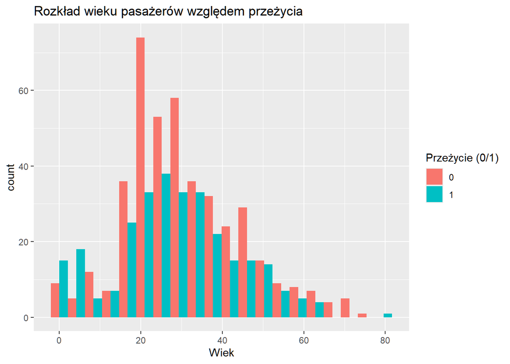

```r
# Wizualizacja zależności między wiekiem a przeżyciem
library(ggplot2)
ggplot(data_titanic, aes(x = Age, fill = factor(Survived))) +
  geom_histogram(bins = 20, position = "dodge") +
  labs(title = "Rozkład wieku pasażerów względem przeżycia", x = "Wiek", fill = "Przeżycie (0/1)")
```

Zastosuję regresję logistyczną, aby sprawdzić współczynniki i istotność zmiennych.

```r
# Regresja logistyczna z wszystkimi zmiennymi
model_logistic_full <- glm(Survived ~ Pclass + Sex + Age + SibSp + Parch + Fare + Embarked,
                           data = data_titanic,
                           family = binomial)

# Podsumowanie wyników
summary(model_logistic_full)
```

```
##
## Call:
## glm(formula = Survived ~ Pclass + Sex + Age + SibSp + Parch +
##     Fare + Embarked, family = binomial, data = data_titanic)
##
## Coefficients:
##               Estimate Std. Error z value Pr(>|z|)
## (Intercept)  17.894850 607.855474   0.029  0.97651
## Pclass       -1.199251   0.164619  -7.285 3.22e-13 ***
## Sexmale      -2.638476   0.222256 -11.871  < 2e-16 ***
## Age          -0.043350   0.008232  -5.266 1.39e-07 ***
## SibSp        -0.363208   0.129017  -2.815  0.00487 **
## Parch        -0.060270   0.123900  -0.486  0.62666
## Fare          0.001432   0.002531   0.566  0.57165
## EmbarkedC   -12.257443 607.855250  -0.020  0.98391
## EmbarkedQ   -13.080988 607.855453  -0.022  0.98283
## EmbarkedS   -12.658656 607.855228  -0.021  0.98339
## ---
## Signif. codes:  0 '***' 0.001 '**' 0.01 '*' 0.05 '.' 0.1 ' ' 1
##
## (Dispersion parameter for binomial family taken to be 1)
##
##     Null deviance: 964.52  on 713  degrees of freedom
## Residual deviance: 632.34  on 704  degrees of freedom
##   (177 obserwacji zostało skasowanych z uwagi na braki w nich zawarte)
## AIC: 652.34
##
## Number of Fisher Scoring iterations: 13
```

## Wpływ predyktorów w modelach

### Regresja logistyczna

Współczynniki regresji logistycznej wskazują na następujące zależności: - **Sex (płeć)**: Bycie mężczyzną zmniejsza szanse na przeżycie (`Estimate = -2.64`). - **Age (wiek)**: Każdy dodatkowy rok życia zmniejsza szansę przeżycia (`Estimate = -0.043`). - **Pclass (klasa biletu)**: Im wyższa klasa biletu (1 -> 3), tym mniejsze szanse na przeżycie (`Estimate = -1.2`). - **SibSp (rodzina)**: Obecność rodzeństwa/małżonka minimalnie zmniejsza szanse przeżycia (`Estimate = -0.36`).

```r
library(randomForest)
# Las losowy z wszystkimi zmiennymi
rf_model_full <- randomForest(Survived ~ Pclass + Sex + Age + SibSp + Parch + Fare + Embarked,
                              data = data_titanic,
                              na.action = na.omit, # Automatyczne usunięcie braków
                              importance = TRUE)
# Ranking zmiennych
importance(rf_model_full) # Ważność zmiennych
```

```
##            %IncMSE IncNodePurity
## Pclass   39.210600     14.830564
## Sex      86.561915     40.452559
## Age      33.613003     23.276743
## SibSp    19.812013      5.924001
## Parch    12.335438      5.102732
## Fare     29.662321     25.027657
## Embarked  8.063672      3.768514
```

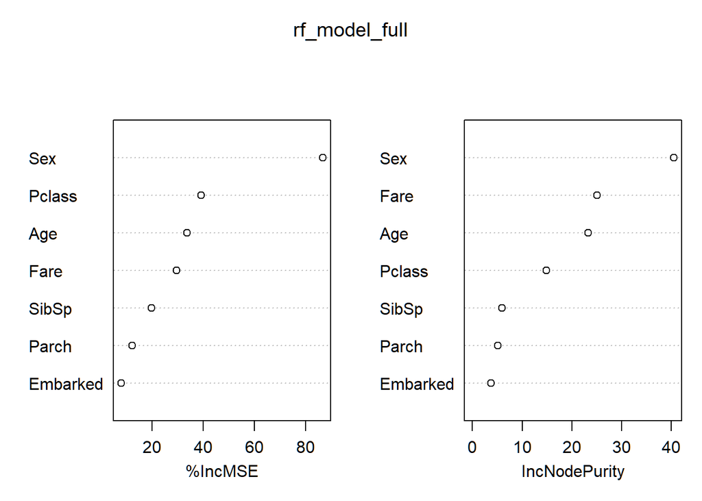

```r
varImpPlot(rf_model_full) # Wykres ważności
```

### Las losowy

Ranking waznosci predyktorow (wg lasu losowego): 1. **Sex (płeć)** 2. **Pclass (klasa biletu)** 3. **Age (wiek)** 4. **Fare (cena biletu)** 5. **SibSp (rodzina)**

Wyniki te potwierdzają kluczowe znaczenie płci, klasy biletu i wieku w przewidywaniu przeżycia

Wnioski po zastosowaniu obu modeli:

Najważniejsze zmienne: 1. Sex - istotny w regresji logistycznej i rf 2. Age - istotny w rl i rf 3. Pclass - istotny w rl i rf 4. Fare - nieistotny w rl, ale istotny w rf 5. SibSP - istotny w rl, srednio istotny w rf Pomijam pozostałe predyktory, ponieważ są nieważne przy analizie.

Dalsze kroki: Czyszczenie danych do przeprowadzenia dalszych analiz:

```r
# Usunięcie wierszy z brakami w kolumnach
data_titanic <- na.omit(data_titanic[, c("Survived", "Sex", "Age", "Pclass", "Fare", "SibSp")])

# Sprawdzenie liczby obserwacji po usunięciu braków
nrow(data_titanic)
```

```
## [1] 714
```

```r
#Sprawdzenie ilosci pustych wierszy w wybranym datasecie
colSums(is.na(data_titanic))
```

```
## Survived      Sex      Age   Pclass     Fare    SibSp
##        0        0        0        0        0        0
```

```r
# Zakodowanie zmiennej Sex
data_titanic$Sex <- ifelse(data_titanic$Sex == "male", 0, 1)

# Sprawdzenie unikalnych wartości
table(data_titanic$Sex) # male <- 0, female <- 1
```

```
##
##   0   1
## 453 261
```

```r
#Podglad danych do dalszej analizy:
head(data_titanic)
```

```
##   Survived Sex Age Pclass    Fare SibSp
## 1        0   0  22      3  7.2500     1
## 2        1   1  38      1 71.2833     1
## 3        1   1  26      3  7.9250     0
## 4        1   1  35      1 53.1000     1
## 5        0   0  35      3  8.0500     0
## 7        0   0  54      1 51.8625     0
```

```r
str(data_titanic)
```

```
## 'data.frame':    714 obs. of  6 variables:
##  $ Survived: int  0 1 1 1 0 0 0 1 1 1 ...
##  $ Sex     : num  0 1 1 1 0 0 0 1 1 1 ...
##  $ Age     : num  22 38 26 35 35 54 2 27 14 4 ...
##  $ Pclass  : int  3 1 3 1 3 1 3 3 2 3 ...
##  $ Fare    : num  7.25 71.28 7.92 53.1 8.05 ...
##  $ SibSp   : int  1 1 0 1 0 0 3 0 1 1 ...
##  - attr(*, "na.action")= 'omit' Named int [1:177] 6 18 20 27 29 30 32 33 37 43 ...
##   ..- attr(*, "names")= chr [1:177] "6" "18" "20" "27" ...
```

```r
library(tree)
# Przekształcenie zmiennej Survived na faktor
data_titanic$Survived <- as.factor(data_titanic$Survived)

tree_model <- tree(Survived ~ Sex + Age + Pclass + Fare + SibSp, data = data_titanic)

#podglad struktury
summary(tree_model)
```

```
##
## Classification tree:
## tree(formula = Survived ~ Sex + Age + Pclass + Fare + SibSp,
##     data = data_titanic)
## Number of terminal nodes:  7
## Residual mean deviance:  0.7975 = 563.9 / 707
## Misclassification error rate: 0.1737 = 124 / 714
```

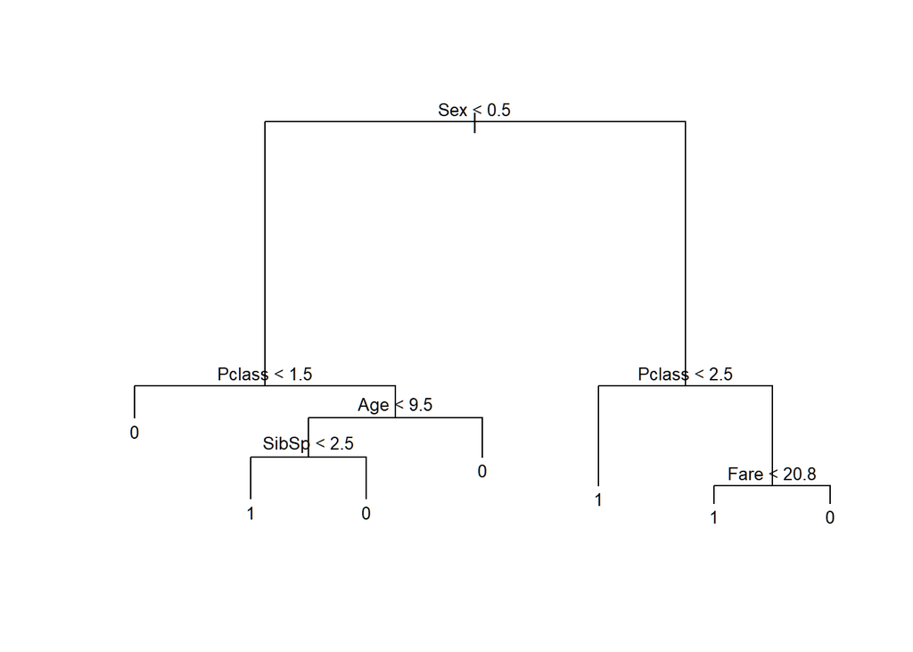

```r
#wizualizacja
plot(tree_model)
text(tree_model, pretty=0, cex=0.8)
```

```r
# Predykcje na zbiorze danych
pred_tree <- predict(tree_model, data_titanic, type = "class")

# Macierz pomyłek
conf_matrix <- table(Predicted = pred_tree, Actual = data_titanic$Survived)
print(conf_matrix)
```

```
##          Actual
## Predicted   0   1
##         0 380  80
##         1  44 210
```

```r
# Wyliczenie dokładności
accuracy_tree <- mean(pred_tree == data_titanic$Survived)
print(paste("Dokładność drzewa decyzyjnego:", round(accuracy_tree * 100, 2), "%"))
```

```
## [1] "Dokładność drzewa decyzyjnego: 82.63 %"
```

```r
# Ustawienie ziarna losowego dla powtarzalności wyników
set.seed(123)

# Podział danych na zbiór treningowy (70%) i testowy (30%)
train_indices <- sample(1:nrow(data_titanic), size = 0.7 * nrow(data_titanic))
train_data <- data_titanic[train_indices, ]
test_data <- data_titanic[-train_indices, ]

# Sprawdzenie liczby obserwacji
nrow(train_data) # Liczba w zbiorze treningowym
```

```
## [1] 499
```

```r
nrow(test_data)  # Liczba w zbiorze testowym
```

```
## [1] 215
```

```r
# Budowa drzewa decyzyjnego na zbiorze treningowym
tree_model <- tree(Survived ~ Sex + Age + Pclass + Fare + SibSp, data = train_data)

# Predykcje na zbiorze testowym
pred_tree <- predict(tree_model, test_data, type = "class")

# Macierz pomyłek dla drzewa decyzyjnego
conf_matrix_tree <- table(Predicted = pred_tree, Actual = test_data$Survived)
print(conf_matrix_tree)
```

```
##          Actual
## Predicted   0   1
##         0 118  36
##         1   3  58
```

```r
# Dokładność drzewa decyzyjnego
accuracy_tree <- mean(pred_tree == test_data$Survived)
print(paste("Dokładność drzewa decyzyjnego na zbiorze testowym:", round(accuracy_tree * 100, 2), "%"))
```

```
## [1] "Dokładność drzewa decyzyjnego na zbiorze testowym: 81.86 %"
```

```r
# Budowa modelu regresji logistycznej
logistic_model <- glm(Survived ~ Sex + Age + Pclass + Fare + SibSp, data = train_data, family = binomial)

# Predykcje na zbiorze testowym (prawdopodobieństwa)
pred_logistic <- predict(logistic_model, test_data, type = "response")

# Zamiana prawdopodobieństw na klasy (0.5 jako próg)
pred_logistic_class <- ifelse(pred_logistic > 0.5, 1, 0)

# Macierz pomyłek dla regresji logistycznej
conf_matrix_logistic <- table(Predicted = pred_logistic_class, Actual = test_data$Survived)
print(conf_matrix_logistic)
```

```
##          Actual
## Predicted   0   1
##         0 110  29
##         1  11  65
```

```r
# Dokładność regresji logistycznej
accuracy_logistic <- mean(pred_logistic_class == test_data$Survived)
print(paste("Dokładność regresji logistycznej na zbiorze testowym:", round(accuracy_logistic * 100, 2), "%"))
```

```
## [1] "Dokładność regresji logistycznej na zbiorze testowym: 81.4 %"
```

```r
# Budowa lasu losowego
rf_model <- randomForest(Survived ~ Sex + Age + Pclass + Fare + SibSp, data = train_data, importance = TRUE)

# Predykcje na zbiorze testowym
pred_rf <- predict(rf_model, test_data)

# Macierz pomyłek dla lasu losowego
conf_matrix_rf <- table(Predicted = pred_rf, Actual = test_data$Survived)
print(conf_matrix_rf)
```

```
##          Actual
## Predicted   0   1
##         0 115  27
##         1   6  67
```

```r
# Dokładność lasu losowego
accuracy_rf <- mean(pred_rf == test_data$Survived)
print(paste("Dokładność lasu losowego na zbiorze testowym:", round(accuracy_rf * 100, 2), "%"))
```

```
## [1] "Dokładność lasu losowego na zbiorze testowym: 84.65 %"
```

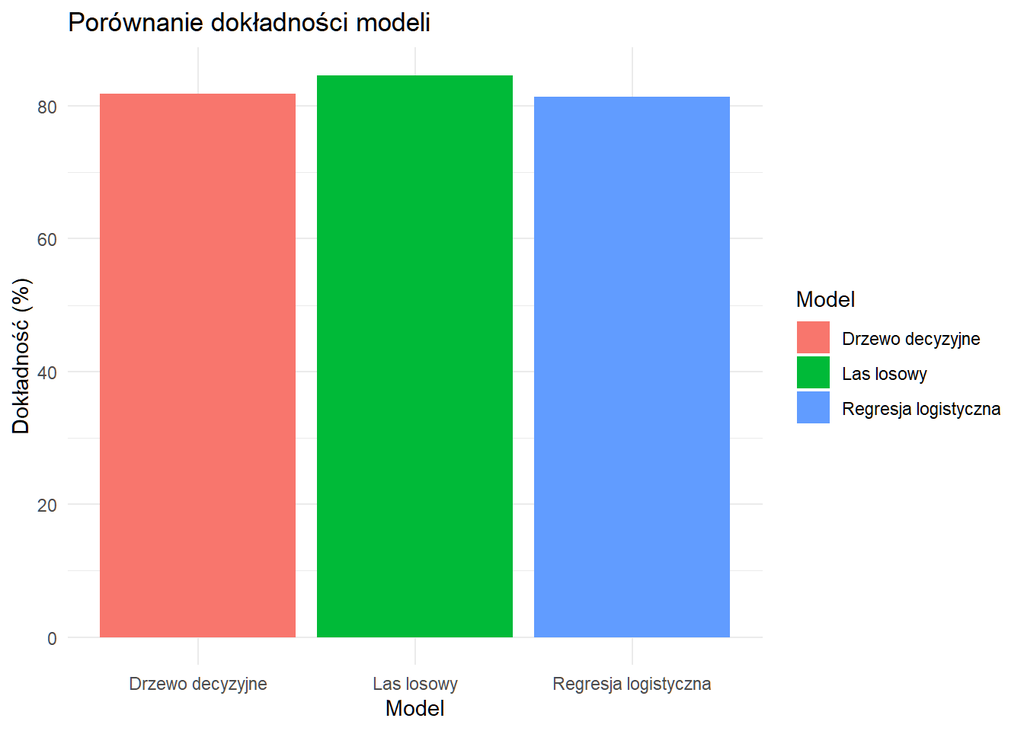

```r
# Porównanie dokładności modeli
accuracy_df <- data.frame(
  Model = c("Drzewo decyzyjne", "Regresja logistyczna", "Las losowy"),
  Accuracy = c(81.86, 81.4, 84.65)
)

library(ggplot2)
ggplot(accuracy_df, aes(x = Model, y = Accuracy, fill = Model)) +
  geom_bar(stat = "identity") +
  labs(title = "Porównanie dokładności modeli", x = "Model", y = "Dokładność (%)") +
  theme_minimal()
```

## Podsumowanie

Projekt miał na celu analizę danych pasażerów Titanica w celu przewidzenia ich przeżycia na podstawie dostępnych cech, takich jak płeć, wiek, klasa biletu i inne. Zrealizowano to za pomocą trzech modeli: regresji logistycznej, drzewa decyzyjnego oraz lasu losowego.

**Kluczowe wnioski:** 1. **Najważniejsze predyktory:** - **Płeć**: Bycie kobietą znacząco zwiększało szanse na przeżycie. - **Wiek**: Młodsi pasażerowie mieli większe szanse na przeżycie. - **Klasa biletu**: Pasażerowie klasy pierwszej mieli najwyższe szanse na przeżycie.

2. **Porównanie modeli:**
   - Las losowy osiągnął najwyższą dokładność (84.65%), przewyższając regresję logistyczną i drzewo decyzyjne.
   - Modele różniły się w ważności predyktorów, co sugeruje ich różne podejścia do analizy danych.

**Znaczenie analizy:** Analiza taka jak ta może być wykorzystywana do nauki modelowania danych i zrozumienia, jak różne cechy wpływają na wyniki. Jest to również dobry przykład porównania różnych modeli i ich zastosowań w praktyce.